# Clase 5 - Programacion Funcional

Diplomatura en Ciencias Sociales Computacionales y Humanidades Digitales - UNSAM

# Introducción

En este material veremos algunas herramientas un poco más avanzadas que sirven para escalar procedimientos que vimos anteriormente y/o para automatizar (parte de) nuestro trabajo. La idea es un primer acercamiento a herramientas que evitan tener que constantemente copiar nuestro código y modificar algunos paramentos o variables, cada vez que queramos realizar procedimientos parecidos.

Trabajaremos con una muestra (de elaboración propia) de la base de casos de covid en Argentina. La misma contiene una selección aleatoria de 2% de los casos diarios registrados por localidad. No se recomienda utilizar esta muestra más que para ejercitación.

```r
library(tidyverse)
library(openxlsx)
base.covid <- readRDS('bases/base_covid_sample.RDS')
```

# Estructuras Condicionales

## if

La función *if* se utilizará para correr código condicionalmente.

Su funcionamiento es el siguiente:  
`if(condicion){codigo a ejecutar si se cumple la condición}`

```r
if( 2+2 == 4){
  print("Todo marcha bien")
}
```

```
## [1] "Todo marcha bien"
```

```r
if( 2+2 == 148.24){
  print("R, tenemos un problema")
}
```

## if + else

La función **if** también puede utilizarse para indicar la ejecución de uno u otro fragmentos de código según se cumpla o no una condición. Para ello, agregamos **`else{}`** y el código a ejecutar en caso de NO cumplimiento de la condición, de la siguiente manera:

`if(condicion){codigo a ejecutar si se cumple la condición} else {codigo a ejecutar si NO se cumple la condición}`

Veamos un ejemplo. Queremos que nuestro código nos indique si la fecha de ejecución del código coincide con la de la última actualización de la base de datos. Caso contrario, queremos que se nos indique la diferencia de tiempo entre ambas.

```r
ultima.actualiz.base<- unique(base.covid$ultima_actualizacion)
ultima.actualiz.base
```

```
## [1] "2021-04-20"
```

¿Es dicha fecha igual a la fecha actual de ejecución del código? Para ello podemos usar la función **Sys.Date()** de RBase

```r
if (ultima.actualiz.base == Sys.Date()) {
    "Datos al día de hoy"
} else{
  paste0("Datos actualizados al ", ultima.actualiz.base)
}
```

```
## [1] "Datos actualizados al 2021-04-20"
```

# Funciones propias

La creación de **funciones** propias nos permite automatizar todas aquellas partes del código que se repiten mucho. Una vez diseñadas, funcionan igual que cualquier comando.

Arranquemos con un ejemplo básico. Podemos crear una función que al indicare dos valores, devuelva la suma de ellos

```r
suma <- function(valor1, valor2) {
  valor1+valor2
}


suma
```

```
## function(valor1, valor2) {
##   valor1+valor2
## }
```

En el paso anterior simplemente creamos una función que se guardará en nuestro ambiente como cualquier otro objeto. Para utilizar la función, debemos hacerlo como con cualquier otra, específicandole los argumentos que queremos que tome.

```r
suma(valor1 = 5,valor2 = 6)
```

```
## [1] 11
```

Obviamente las funciones no son sólo para variables numéricas. Por ejemplo, podemos pegar dos strings con una flecha en el medio

```r
funcion_prueba <- function(parametro1,parametro2) {
  paste(parametro1, parametro2, sep = " <--> ")
}

funcion_prueba(parametro1 = "A ver", parametro2 = "que pasa")
```

```
## [1] "A ver <--> que pasa"
```

También podemos asignar un **valor por default** para alguno de los parametros. Este es el valor que va a tomar el parametro en caso de que el usuario no lo defina al ejecutar la función

```r
Otra_funcion_prueba <- function(parametro1,
                                parametro2 = "colgado") {

   paste(parametro1, parametro2, sep = ", ")

}
```

Veamos que pasa al ejecutar la función completando solo el parametro 1:

```r
Otra_funcion_prueba(parametro1 = "Hola")
```

```
## [1] "Hola, colgado"
```

Las funciones que creamos nosotros permanecen en el ambiente de R temporariamente. Cuando removemos los objetos del ambiente, la función deja de existir. Por ende, debemos incorporarla en cada uno de los scripts en la cual la necesitemos. Una buena práctica, es incorporar nuestras funciones útiles al comienzo de cada script junto a la carga de las librerías.

Vale mencionar que **lo que ocurre en una función, queda en la función** excepto que explícitamente estemos devolviendo el resultado “en consola”. Podemos imprimir pasos intermedios para que se visualicen al correr la función incluyendo el comando `print()`.

Las funciones siempre devuelven el último objeto que se crea en ellas, o si explicitamente se utiliza el comando `return()`.

Para ver esto, voy a diseñar una función que calcule el ratio entre el valor máximo de un vector y el valor mínimo:

```r
calcula_ratio <- function(vector) {

vector.max  <-   max(vector)
vector.min  <-   min(vector)

return(vector.max/vector.min)
}
```

Al correr una función definida de esta manera, en el ambiente solo se conserva en nuestro objeto **ratio** el valor devuelto con `return()`. *vector.max* y *vector.min* no quedan almacenados.

```r
ratio <- calcula_ratio(vector = c(1,2,3,4))

ratio
```

```
## [1] 4
```

Ahora bien, cuando pensamos en funciones más complejas cuya operatoria no es tan obvia, pueden agregarse chequeos, y operatorias condicionales con alguna advertencia para que el usuario pueda comprender un error, o tenga mayor noción de qué está haciendo la función.

Que pasa si el usuario de la función no pasa un vector numérico?

```r
calcula_ratio(vector = c(1,2,3,4,"H"))
```

```
## Error in vector.max/vector.min: argumento no-numérico para operador binario
```

En este caso, podríamos haber seteado un mensaje más amigable que permita al usuario comprender su error. Lo podemos hacer con el paquete **assertthat**

```r
calcula_ratio <- function(vector) {

assertthat::assert_that(is.numeric(vector),
                        msg = "Ingresá un vector numérico!")


vector.max  <-   max(vector)
vector.min  <-   min(vector)


return(vector.max/vector.min)
}

calcula_ratio(vector = c(1,2,3,4,"H"))
```

```
## Error: Ingresá un vector numérico!
```

Una vuelta de tuerca más! Qué pasa si dentro del vector tenemos un 0?

```r
calcula_ratio(vector = c(1,2,3,4,0))
```

```
## [1] Inf
```

Supongamos que queremos que en ese caso nuestra función descarte ese valor, calcule igualmente el ratio, pero dando aviso de ello

```r
calcula_ratio <- function(vector) {

assertthat::assert_that(is.numeric(vector),
                        msg = "Ingresa un vector numérico")

if(any(vector==0)){

  warning("Mensaje: Hay un cero en tu vector, no lo tomo en cuenta para el calculo")
  vector <- vector[vector!=0]

}
vector.max  <-   max(vector)
vector.min  <-   min(vector)


return(vector.max/vector.min)
}
```

Veamos que pasa

```r
calcula_ratio(vector = c(1,0,3,4))
```

```
## Warning in calcula_ratio(vector = c(1, 0, 3, 4)): Mensaje: Hay un cero en tu
## vector, no lo tomo en cuenta para el calculo
```

```
## [1] 4
```

# Loops

Un **loop** es una estructura de código que nos permite aplicar iterativamente un mismo conjunto de comandos, variando el valor de una variable. Veremos aquí únicamente el loop **for**, cuya sintaxis es la siguiente:

`for (variable in vector) {conjunto de procedimientos a realizar}`

```r
for(i in 1:10){
   print(i^2)

}
```

```
## [1] 1
## [1] 4
## [1] 9
## [1] 16
## [1] 25
## [1] 36
## [1] 49
## [1] 64
## [1] 81
## [1] 100
```

Esto se lee como : “Recorre cada uno de los valores (i) del vector numérico 1 a 10, y para cada uno de ellos imprimí el cuadrado (i^2)”.  
Uno puede especificar la palabra que desee que tomé cada uno de los valores que debe tomar. En el ejemplo anterior fue **i**, pero bien podría ser la “**Valores**”

```r
for(Valores in 1:10){
   print(Valores^2)

}
```

```
## [1] 1
## [1] 4
## [1] 9
## [1] 16
## [1] 25
## [1] 36
## [1] 49
## [1] 64
## [1] 81
## [1] 100
```

Un loop puede iterar sobre cualquier tipo de vector, independientemente de lo que contenga.

**Una utilización típica de los loops**: Recorrer las categorías de una variable y hacer el mismo gráfico para cada una de ellas.

Vamos a pedirle perdón a lxs docentes del módulo de visualización, y ver un ejemplo con un gráfico super sencillo. Queremos un histograma de la cantidad de registros por edad, según la clasificación del caso. Veamos que categorías toma la variable `clasificacion_resumen`

```r
clasificacion.casos<- unique(base.covid$clasificacion_resumen)
clasificacion.casos
```

```
## [1] "Descartado"     "Confirmado"     "Sospechoso"     "Sin Clasificar"
```

**Recomendación:** Antes de hacer un loop (ya sea para gráficos u otros procesamientos), prueben primero obtener lo que quieren para una categoría, y luego lo extienden hacia el resto. En este sentido, armemos el gráfico para la categoría “Confirmado”

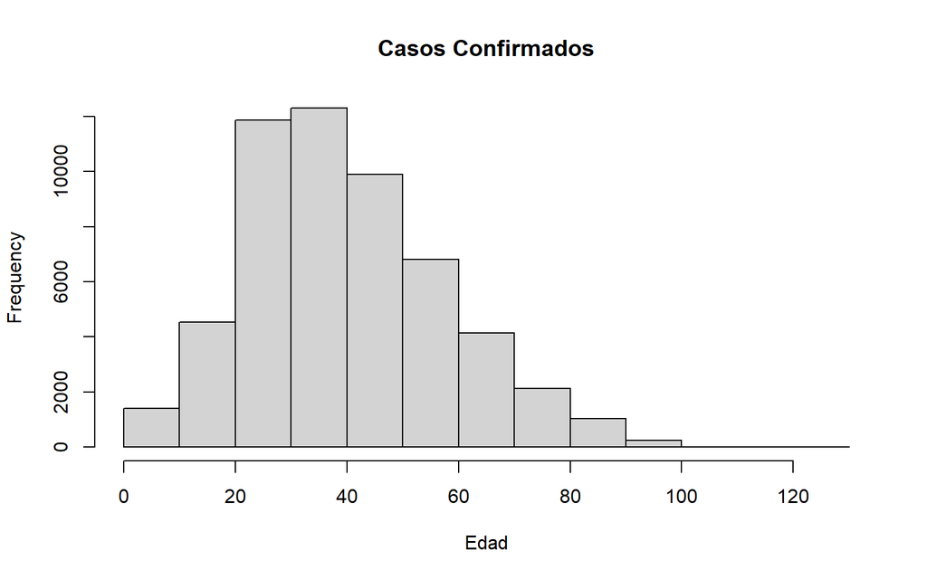

```r
base.confirmados  <- base.covid %>%
    filter(clasificacion_resumen  == "Confirmado")


hist(x = base.confirmados$edad,
     main = "Casos Confirmados",
     xlab = "Edad",
     xlim = c(0,130))
```

Una vez que tenemos el gráfico que nos gusta, ahora si armemos el *loop*.

¿Cómo operar con un loop sobre la base de datos? Lo más frecuente es que querramos realizar un mismo procedimiento sobre distintos valores de cierta variable de nuestra base. Para eso es util el vector `clasificacion.casos` que indicaba las cateogrías que tomaba nuestra variable de interés. Ese vector será el que utilizaremos para iterar.

Miren las diferecias entre el código anterior y el siguiente:

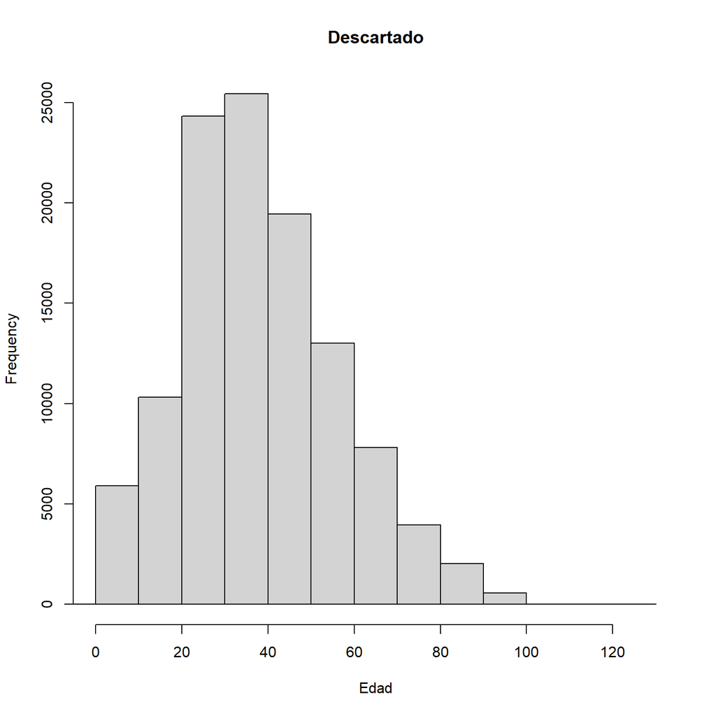

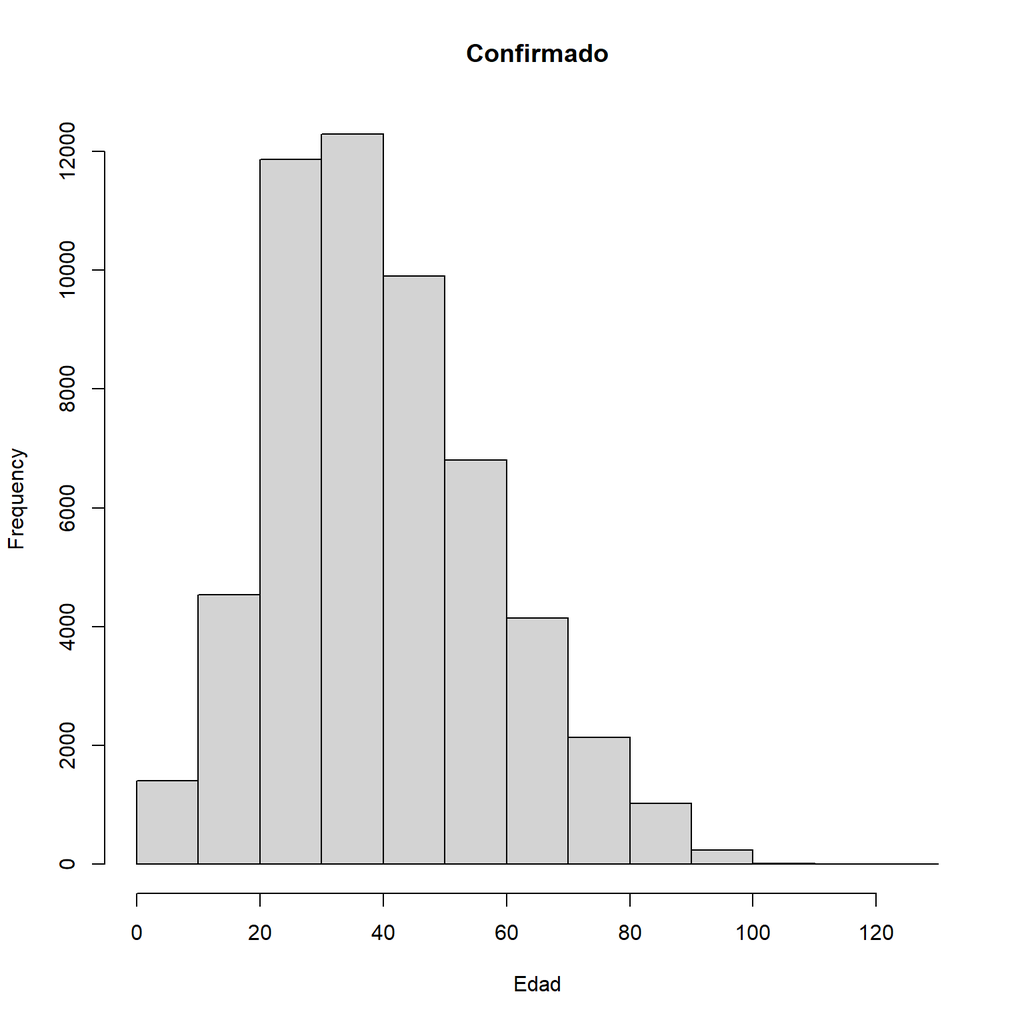

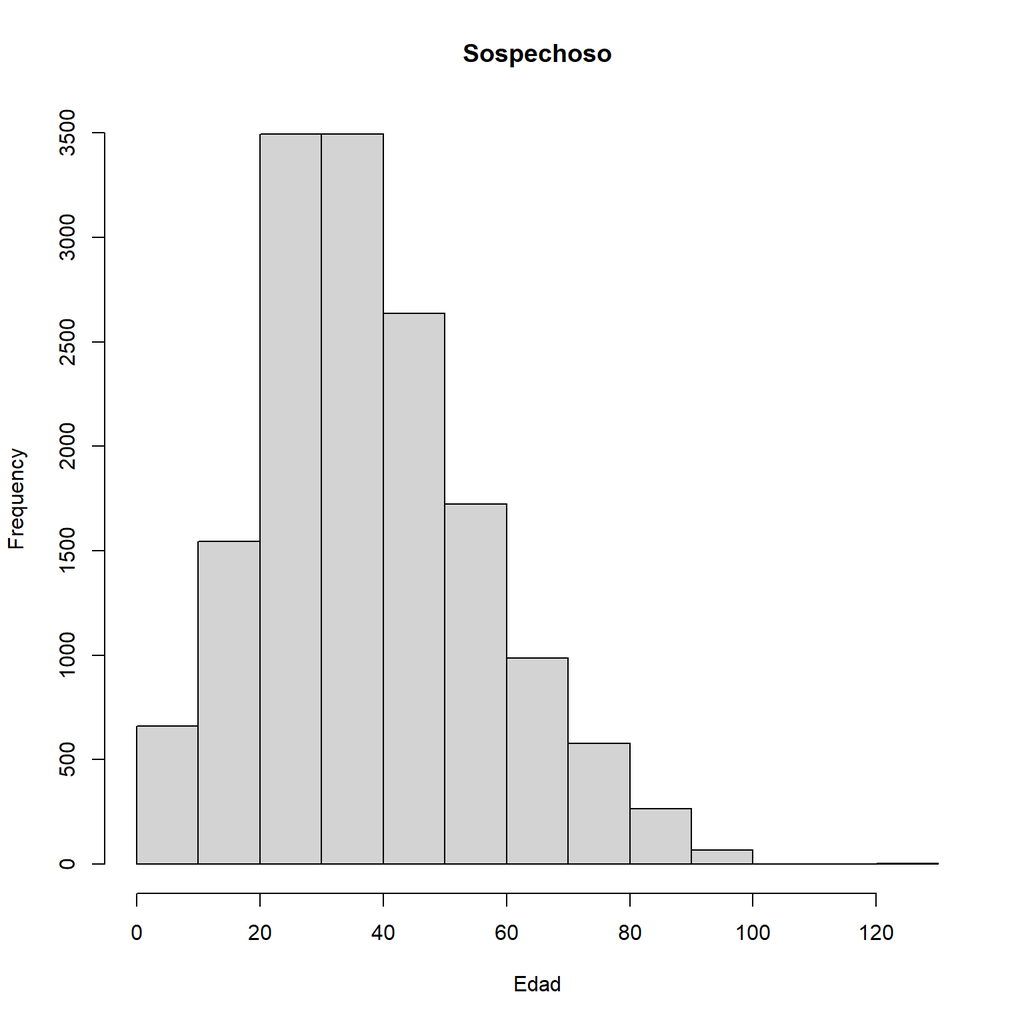

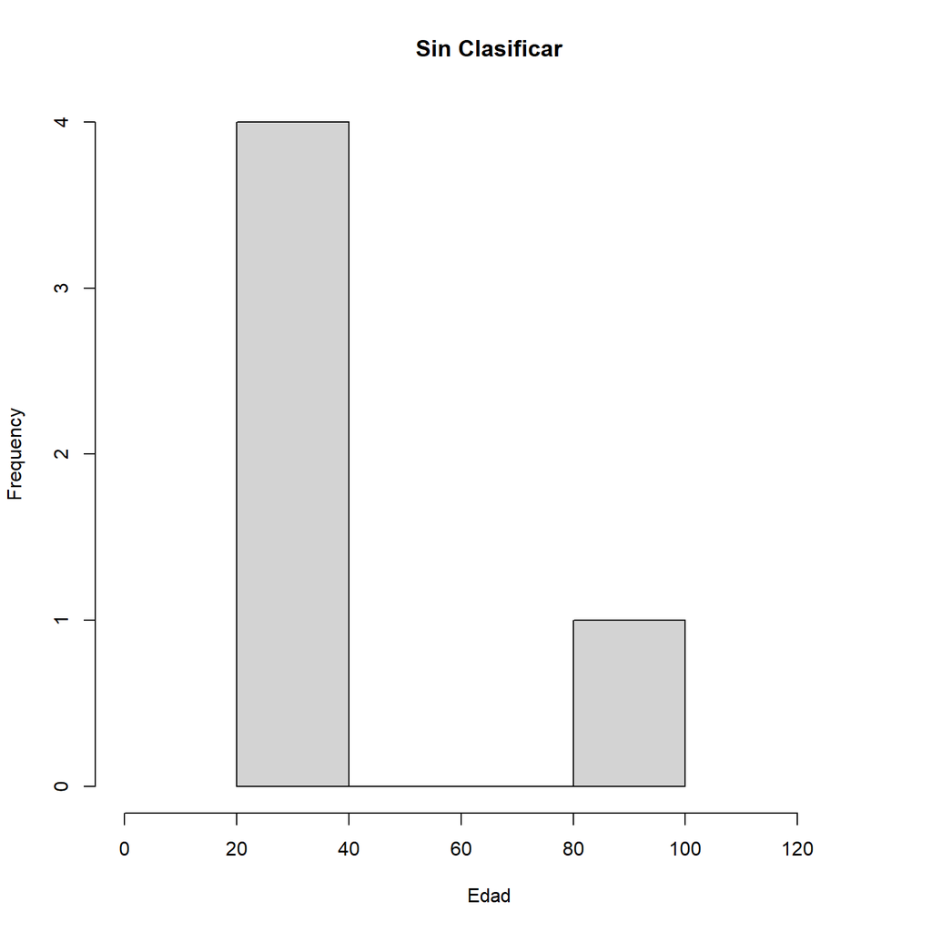

```r
for(categoria in clasificacion.casos){

base.filtrada  <- base.covid %>%
    filter(clasificacion_resumen  == categoria)


hist(x = base.filtrada$edad,
     main = categoria,
     xlab = "Edad",
     xlim = c(0,130))


}
```

Hagamos el mismo loop para la variable de fallecidos, para darle más sentido al ejercicio.

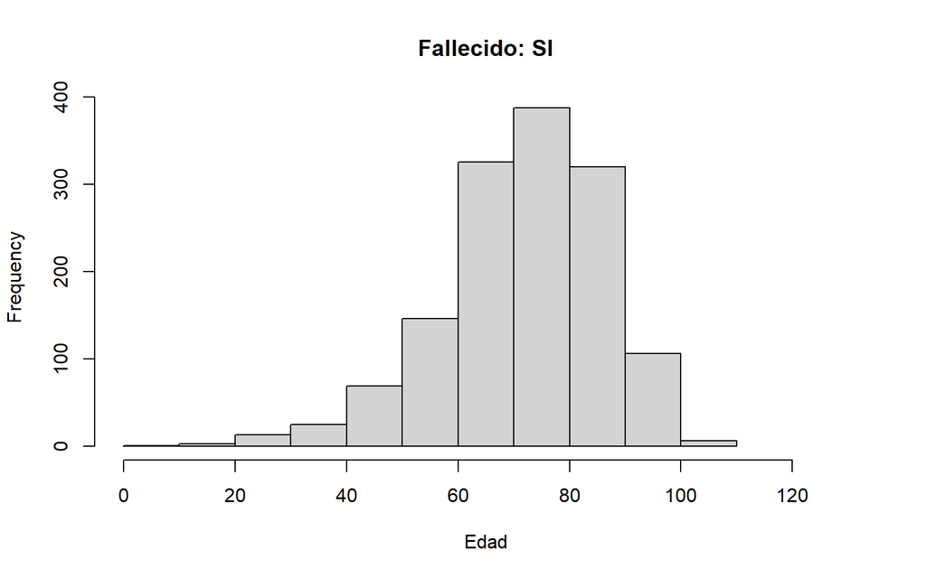

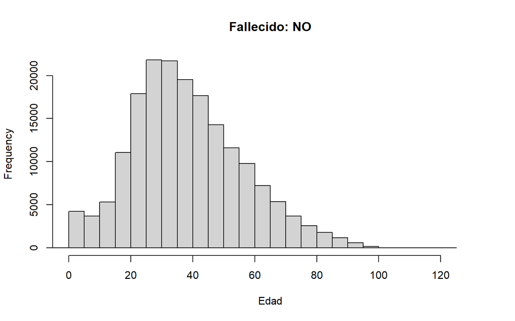

```r
for(categoria in c("SI","NO")){

base.filtrada  <- base.covid %>%
    filter(fallecido  == categoria)

hist(x = base.filtrada$edad,
     main = paste0("Fallecido: ",categoria),
     xlab = "Edad",
     xlim = c(0,130))
}
```

# Exportar resultados a Excel

La función **write.xlsx** de la libreria [openxlsx](https://ycphs.github.io/openxlsx/) nos permite exportar uno o más dataframes a una o más pestañas de un archivo de Excel. Hay una infinidad de variantes para hacer la exportación. Podemos destacar algunas funcionalidades para:  
- Agregar títulos a los cuadros  
- Apilar múltiples dataframes en una misma solapa del excel  
- Agregar colores y/o bordes a los cuadros  
- Cambiar la fuente del texto exportado

Todas estas variantes, con ejemplos, se pueden consultar [acá](https://ycphs.github.io/openxlsx/articles/Introduction.html).

Supongamos que queremos un cuadro que nos muestre la cantidad de casos, según `clasificacion_resumen` y `provincia`.

```r
cuadro_por_provincia<- base.covid %>%
  group_by(residencia_provincia_nombre,clasificacion_resumen) %>%
  summarise(casos = n())
```

La forma más simple, como ya vimos sólo requiere indicar el dataframe a exportar, y la ruta completa, con extensión del archivo incluido.

```r
dir.create("Resultados")#Si quiero crear una nueva carpeta

openxlsx::write.xlsx(x = cuadro_por_provincia,
                     file ="Resultados/miexportacion.xlsx")
```

La alternativa que me permite exportar datos con más chiches, tiene la siguiente forma:

-`createWorkbook()`: Creo un objeto Workbook en mi ambiente  
-`addWorksheet()`: Le agrego a ese objeto una pestaña/hoja de excel  
-`writeData()`: Le agrego la data que quiera a una determinada pestaña del excel (creada previamente). **Acá puedo ajustar todo tipo de parámetros estéticos**  
-`saveWorkbook()`: Guardo el excel creado (lo creará en mi disco de la computadora)

```r
wb <- createWorkbook()

addWorksheet(wb,sheetName =  "Casos Provincias")

writeData(wb,
          sheet="Casos Provincias",
          x = "Cuadro 1. Cantidad de Casos por provincia", #Lo uso para crear un titulo
          startRow = 1)


writeData(wb,
          sheet="Casos Provincias",
          x = cuadro_por_provincia,   #Acá va la base de datos
          borders = "rows" ,#Parametro de Estilo
          borderStyle = "dashed", #Parametro de Estilo
          startRow = 3) #Dejo un espacio entre titulo y datos

saveWorkbook(wb, "Resultados/miexportacion_piola.xlsx")
```

# Loops + Exportacion de Excels

Un ejemplo típico es la necesidad de exportar a varias pestañas de un excel cada data.frame que surge como resultado de un loop. Iteremos sobre el cuadro anterior, para exportar en una pestaña distinta los resultados para cada provincia:

```r
provincias <- unique(cuadro_por_provincia$residencia_provincia_nombre)

wb <- createWorkbook() #Creo nuevo libro



for (prov in provincias) {

  #Este cuadro ira cambiando de provincia a medida que avanza el loop
cuadro.prov <- cuadro_por_provincia %>%
    filter(residencia_provincia_nombre == prov)

addWorksheet(wb, sheetName =  prov) #Al poner "prov" estoy agregando una pestaña con cada nombre de provincia

writeData(wb,                #Especifico mi base de datos
          sheet=prov,
          x = cuadro.prov,
          startRow = 1)

}

saveWorkbook(wb, "Resultados/miexportacion_loop.xlsx")
```